# 21-01 주제분석 1주차 패키지

```python
import numpy as np
import pandas as pd
```

# 1. 데이터 전처리

## 1.1 데이터 불러오기

```python
data=pd.read_csv('C:/Users/paa04/OneDrive/바탕 화면/P-SAT/21-1/데마/클린업/주제분석 1주차 패키지/주제분석 1주차/data.csv')
```

## 1.2 데이터 확인

```python
data.shape
```

```
(1216553, 13)
```

```python
data.head
```

```
<bound method NDFrame.head of          transaction_id  apartment_id   city     dong   jibun         apt  \
0                     0          7622  서울특별시      신교동    6-13    신현(101동)
1                     1          5399  서울특별시      필운동     142      사직파크맨션
2                     2          3578  서울특별시      필운동   174-1      두레엘리시안
3                     3         10957  서울특별시      내수동      95       파크팰리스
4                     4         10639  서울특별시      내수동  110-15        킹스매너
...                 ...           ...    ...      ...     ...         ...
1216548         1234823          9578  부산광역시  정관읍 용수리    1387  정관 동일스위트1차
1216549         1234824          9578  부산광역시  정관읍 용수리    1387  정관 동일스위트1차
1216550         1234825          9578  부산광역시  정관읍 용수리    1387  정관 동일스위트1차
1216551         1234826          9586  부산광역시  정관읍 용수리    1364   정관신도시롯데캐슬
1216552         1234827          9578  부산광역시  정관읍 용수리    1387  정관 동일스위트1차

                         addr_kr  exclusive_use_area  year_of_completion  \
0              신교동 6-13 신현(101동)             84.8200                2002
```

[output cut: 38 more lines]

```python
data.info
```

```
<bound method DataFrame.info of          transaction_id  apartment_id   city     dong   jibun         apt  \
0                     0          7622  서울특별시      신교동    6-13    신현(101동)
1                     1          5399  서울특별시      필운동     142      사직파크맨션
2                     2          3578  서울특별시      필운동   174-1      두레엘리시안
3                     3         10957  서울특별시      내수동      95       파크팰리스
4                     4         10639  서울특별시      내수동  110-15        킹스매너
...                 ...           ...    ...      ...     ...         ...
1216548         1234823          9578  부산광역시  정관읍 용수리    1387  정관 동일스위트1차
1216549         1234824          9578  부산광역시  정관읍 용수리    1387  정관 동일스위트1차
1216550         1234825          9578  부산광역시  정관읍 용수리    1387  정관 동일스위트1차
1216551         1234826          9586  부산광역시  정관읍 용수리    1364   정관신도시롯데캐슬
1216552         1234827          9578  부산광역시  정관읍 용수리    1387  정관 동일스위트1차

                         addr_kr  exclusive_use_area  year_of_completion  \
0              신교동 6-13 신현(101동)             84.8200                2002
```

[output cut: 38 more lines]

```python
data.isnull()
```

|  | transaction_id | apartment_id | city | dong | jibun | apt | addr_kr | exclusive_use_area | year_of_completion | transaction_year_month | transaction_date | floor | transaction_real_price |
| --- | --- | --- | --- | --- | --- | --- | --- | --- | --- | --- | --- | --- | --- |
| 0 | False | False | False | False | False | False | False | False | False | False | False | False | False |
| 1 | False | False | False | False | False | False | False | False | False | False | False | False | False |
| 2 | False | False | False | False | False | False | False | False | False | False | False | False | False |
| 3 | False | False | False | False | False | False | False | False | False | False | False | False | False |
| 4 | False | False | False | False | False | False | False | False | False | False | False | False | False |
| ... | ... | ... | ... | ... | ... | ... | ... | ... | ... | ... | ... | ... | ... |
| 1216548 | False | False | False | False | False | False | False | False | False | False | False | False | False |
| 1216549 | False | False | False | False | False | False | False | False | False | False | False | False | False |
| 1216550 | False | False | False | False | False | False | False | False | False | False | False | False | False |
| 1216551 | False | False | False | False | False | False | False | False | False | False | False | False | False |
| 1216552 | False | False | False | False | False | False | False | False | False | False | False | False | False |

1216553 rows × 13 columns

```python
data.isnull().sum()
```

```
transaction_id            0
apartment_id              0
city                      0
dong                      0
jibun                     0
apt                       0
addr_kr                   0
exclusive_use_area        0
year_of_completion        0
transaction_year_month    0
transaction_date          0
floor                     0
transaction_real_price    0
dtype: int64
```

## 1.3 불필요한 행 삭제(reset index)

city 컬럼에 서울과 부산이 있는데 서울인 행만 남기고 인덱스 재정렬

```python
data['city']
```

```
0          서울특별시
1          서울특별시
2          서울특별시
3          서울특별시
4          서울특별시
           ...
1216548    부산광역시
1216549    부산광역시
1216550    부산광역시
1216551    부산광역시
1216552    부산광역시
Name: city, Length: 1216553, dtype: object
```

```python
dat2=data.drop(data.loc[data['city']=='부산광역시'].index)
dat2.reset_index
```

```
<bound method DataFrame.reset_index of          transaction_id  apartment_id   city dong   jibun        apt  \
0                     0          7622  서울특별시  신교동    6-13   신현(101동)
1                     1          5399  서울특별시  필운동     142     사직파크맨션
2                     2          3578  서울특별시  필운동   174-1     두레엘리시안
3                     3         10957  서울특별시  내수동      95      파크팰리스
4                     4         10639  서울특별시  내수동  110-15       킹스매너
...                 ...           ...    ...  ...     ...        ...
1184014         1196844           996  서울특별시  강일동     717  고덕리엔파크2단지
1184015         1196846           682  서울특별시  강일동     674  강일리버파크3단지
1184016         1196847           682  서울특별시  강일동     674  강일리버파크3단지
1184017         1196848           680  서울특별시  강일동     665  강일리버파크1단지
1184018         1196849           996  서울특별시  강일동     717  고덕리엔파크2단지

                   addr_kr  exclusive_use_area  year_of_completion  \
0        신교동 6-13 신현(101동)               84.82                2002
```

[output cut: 38 more lines]

## 1.4 변수 이름 바꾸기

transaction_real_price를 price로 (너무 길어서)

```python
dat2.rename(columns={'transaction_real_price':'price'}, inplace=True)
dat2.columns
```

```
Index(['transaction_id', 'apartment_id', 'city', 'dong', 'jibun', 'apt',
       'addr_kr', 'exclusive_use_area', 'year_of_completion',
       'transaction_year_month', 'transaction_date', 'floor', 'price'],
      dtype='object')
```

## 1.5 불필요한 변수 삭제

transaction_id는 인덱스이니 삭제, apartment_id는 다른 변수와 겹치니 삭제, jibun변수는 너무 지엽적&유의미x 삭제, city는 서울 하나뿐이니 삭제

```python
df1=dat2.drop(['transaction_id','apartment_id','jibun','city'], axis=1)
df1.columns
```

```
Index(['dong', 'apt', 'addr_kr', 'exclusive_use_area', 'year_of_completion',
       'transaction_year_month', 'transaction_date', 'floor', 'price'],
      dtype='object')
```

## 1.6 연/월 뽑기

동시 기재된 연도와 월을 분리해 새로운 컬럼으로 저장해주기

```python
df1['transaction_year_month']
```

```
0          200801
1          200801
2          200801
3          200801
4          200801
            ...
1184014    201711
1184015    201711
1184016    201711
1184017    201711
1184018    201711
Name: transaction_year_month, Length: 742285, dtype: int64
```

```python
df1['transaction_year_month']=df1['transaction_year_month'].astype(str)
df1['transaction_year']=df1.transaction_year_month.str[0:4]
df1['transaction_month']=df1.transaction_year_month.str[4:6]
```

## 1.7 필요 연도 뽑기

너무 오래전의 데이터는 현재 가격에 유의미한 영향 미치지 않으니 2012년도부터의 데이터만 뽑아오기

```python
df1['transaction_year']
```

```
0          2008
1          2008
2          2008
3          2008
4          2008
           ...
1184014    2017
1184015    2017
1184016    2017
1184017    2017
1184018    2017
Name: transaction_year, Length: 742285, dtype: object
```

```python
df1
```

|  | dong | apt | addr_kr | exclusive_use_area | year_of_completion | transaction_year_month | transaction_date | floor | price | transaction_year | transaction_month |
| --- | --- | --- | --- | --- | --- | --- | --- | --- | --- | --- | --- |
| 0 | 신교동 | 신현(101동) | 신교동 6-13 신현(101동) | 84.82 | 2002 | 200801 | 21~31 | 2 | 37500 | 2008 | 01 |
| 1 | 필운동 | 사직파크맨션 | 필운동 142 사직파크맨션 | 99.17 | 1973 | 200801 | 1~10 | 6 | 20000 | 2008 | 01 |
| 2 | 필운동 | 두레엘리시안 | 필운동 174-1 두레엘리시안 | 84.74 | 2007 | 200801 | 1~10 | 6 | 38500 | 2008 | 01 |
| 3 | 내수동 | 파크팰리스 | 내수동 95 파크팰리스 | 146.39 | 2003 | 200801 | 11~20 | 15 | 118000 | 2008 | 01 |
| 4 | 내수동 | 킹스매너 | 내수동 110-15 킹스매너 | 194.43 | 2004 | 200801 | 21~31 | 3 | 120000 | 2008 | 01 |
| ... | ... | ... | ... | ... | ... | ... | ... | ... | ... | ... | ... |
| 1184014 | 강일동 | 고덕리엔파크2단지 | 강일동 717 고덕리엔파크2단지 | 59.72 | 2011 | 201711 | 11~20 | 9 | 53000 | 2017 | 11 |
| 1184015 | 강일동 | 강일리버파크3단지 | 강일동 674 강일리버파크3단지 | 59.87 | 2009 | 201711 | 21~30 | 12 | 53000 | 2017 | 11 |
| 1184016 | 강일동 | 강일리버파크3단지 | 강일동 674 강일리버파크3단지 | 84.74 | 2009 | 201711 | 21~30 | 3 | 56500 | 2017 | 11 |
| 1184017 | 강일동 | 강일리버파크1단지 | 강일동 665 강일리버파크1단지 | 84.74 | 2009 | 201711 | 21~30 | 9 | 55500 | 2017 | 11 |
| 1184018 | 강일동 | 고덕리엔파크2단지 | 강일동 717 고덕리엔파크2단지 | 84.98 | 2011 | 201711 | 21~30 | 8 | 63750 | 2017 | 11 |

742285 rows × 11 columns

```python
df=df1.loc[df1['transaction_year'] >= '2012',:].reset_index()
df
```

|  | index | dong | apt | addr_kr | exclusive_use_area | year_of_completion | transaction_year_month | transaction_date | floor | price | transaction_year | transaction_month |
| --- | --- | --- | --- | --- | --- | --- | --- | --- | --- | --- | --- | --- |
| 0 | 1770 | 사직동 | 광화문풍림스페이스본(9-0) | 사직동 9 광화문풍림스페이스본(9-0) | 95.88 | 2008 | 201201 | 1~10 | 6 | 70000 | 2012 | 01 |
| 1 | 1771 | 사직동 | 광화문풍림스페이스본(9-0) | 사직동 9 광화문풍림스페이스본(9-0) | 108.55 | 2008 | 201201 | 11~20 | 11 | 100500 | 2012 | 01 |
| 2 | 1772 | 사직동 | 광화문풍림스페이스본(9-0) | 사직동 9 광화문풍림스페이스본(9-0) | 94.51 | 2008 | 201201 | 11~20 | 1 | 65800 | 2012 | 01 |
| 3 | 1773 | 수송동 | 로얄팰리스스위트 | 수송동 85 로얄팰리스스위트 | 42.87 | 2005 | 201201 | 1~10 | 8 | 30500 | 2012 | 01 |
| 4 | 1774 | 수송동 | 로얄팰리스스위트 | 수송동 85 로얄팰리스스위트 | 39.67 | 2005 | 201201 | 21~31 | 15 | 30500 | 2012 | 01 |
| ... | ... | ... | ... | ... | ... | ... | ... | ... | ... | ... | ... | ... |
| 513523 | 1184014 | 강일동 | 고덕리엔파크2단지 | 강일동 717 고덕리엔파크2단지 | 59.72 | 2011 | 201711 | 11~20 | 9 | 53000 | 2017 | 11 |
| 513524 | 1184015 | 강일동 | 강일리버파크3단지 | 강일동 674 강일리버파크3단지 | 59.87 | 2009 | 201711 | 21~30 | 12 | 53000 | 2017 | 11 |
| 513525 | 1184016 | 강일동 | 강일리버파크3단지 | 강일동 674 강일리버파크3단지 | 84.74 | 2009 | 201711 | 21~30 | 3 | 56500 | 2017 | 11 |
| 513526 | 1184017 | 강일동 | 강일리버파크1단지 | 강일동 665 강일리버파크1단지 | 84.74 | 2009 | 201711 | 21~30 | 9 | 55500 | 2017 | 11 |
| 513527 | 1184018 | 강일동 | 고덕리엔파크2단지 | 강일동 717 고덕리엔파크2단지 | 84.98 | 2011 | 201711 | 21~30 | 8 | 63750 | 2017 | 11 |

513528 rows × 12 columns

```python
pd.unique(df['transaction_year'])
```

```
array(['2012', '2013', '2014', '2015', '2016', '2017'], dtype=object)
```

```python
df.columns
```

```
Index(['index', 'dong', 'apt', 'addr_kr', 'exclusive_use_area',
       'year_of_completion', 'transaction_year_month', 'transaction_date',
       'floor', 'price', 'transaction_year', 'transaction_month'],
      dtype='object')
```

column에 index라는게 추가되어 있어서 삭제!

```python
df=df.drop(['index'], axis=1)
df.columns
```

```
Index(['dong', 'apt', 'addr_kr', 'exclusive_use_area', 'year_of_completion',
       'transaction_year_month', 'transaction_date', 'floor', 'price',
       'transaction_year', 'transaction_month'],
      dtype='object')
```

```python
df
```

|  | dong | apt | addr_kr | exclusive_use_area | year_of_completion | transaction_year_month | transaction_date | floor | price | transaction_year | transaction_month |
| --- | --- | --- | --- | --- | --- | --- | --- | --- | --- | --- | --- |
| 0 | 사직동 | 광화문풍림스페이스본(9-0) | 사직동 9 광화문풍림스페이스본(9-0) | 95.88 | 2008 | 201201 | 1~10 | 6 | 70000 | 2012 | 01 |
| 1 | 사직동 | 광화문풍림스페이스본(9-0) | 사직동 9 광화문풍림스페이스본(9-0) | 108.55 | 2008 | 201201 | 11~20 | 11 | 100500 | 2012 | 01 |
| 2 | 사직동 | 광화문풍림스페이스본(9-0) | 사직동 9 광화문풍림스페이스본(9-0) | 94.51 | 2008 | 201201 | 11~20 | 1 | 65800 | 2012 | 01 |
| 3 | 수송동 | 로얄팰리스스위트 | 수송동 85 로얄팰리스스위트 | 42.87 | 2005 | 201201 | 1~10 | 8 | 30500 | 2012 | 01 |
| 4 | 수송동 | 로얄팰리스스위트 | 수송동 85 로얄팰리스스위트 | 39.67 | 2005 | 201201 | 21~31 | 15 | 30500 | 2012 | 01 |
| ... | ... | ... | ... | ... | ... | ... | ... | ... | ... | ... | ... |
| 513523 | 강일동 | 고덕리엔파크2단지 | 강일동 717 고덕리엔파크2단지 | 59.72 | 2011 | 201711 | 11~20 | 9 | 53000 | 2017 | 11 |
| 513524 | 강일동 | 강일리버파크3단지 | 강일동 674 강일리버파크3단지 | 59.87 | 2009 | 201711 | 21~30 | 12 | 53000 | 2017 | 11 |
| 513525 | 강일동 | 강일리버파크3단지 | 강일동 674 강일리버파크3단지 | 84.74 | 2009 | 201711 | 21~30 | 3 | 56500 | 2017 | 11 |
| 513526 | 강일동 | 강일리버파크1단지 | 강일동 665 강일리버파크1단지 | 84.74 | 2009 | 201711 | 21~30 | 9 | 55500 | 2017 | 11 |
| 513527 | 강일동 | 고덕리엔파크2단지 | 강일동 717 고덕리엔파크2단지 | 84.98 | 2011 | 201711 | 21~30 | 8 | 63750 | 2017 | 11 |

513528 rows × 11 columns

# 2. 데이터 시각화

```python
import matplotlib.pyplot as plt
import seaborn as sns
```

## 2.1 거래가격 분포 확인

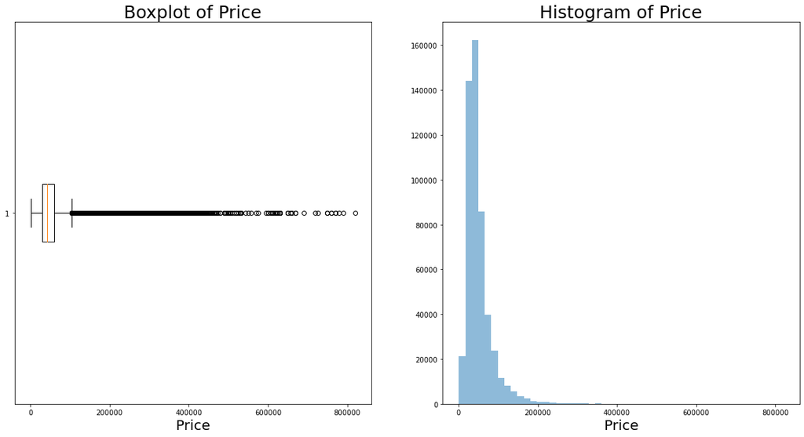

```python
firstplot=plt.figure(figsize=(20,10))
axes1 = firstplot.add_subplot(1,2,1)
axes2 = firstplot.add_subplot(1,2,2)

axes1.boxplot(df['price'], vert=False)
axes1.set_title('Boxplot of Price', fontsize=25)
axes1.set_xlabel('Price', fontsize=20)

axes2.hist(df['price'],bins=50, alpha=0.5)
axes2.set_title('Histogram of Price', fontsize=25)
axes2.set_xlabel('Price', fontsize=20)
```

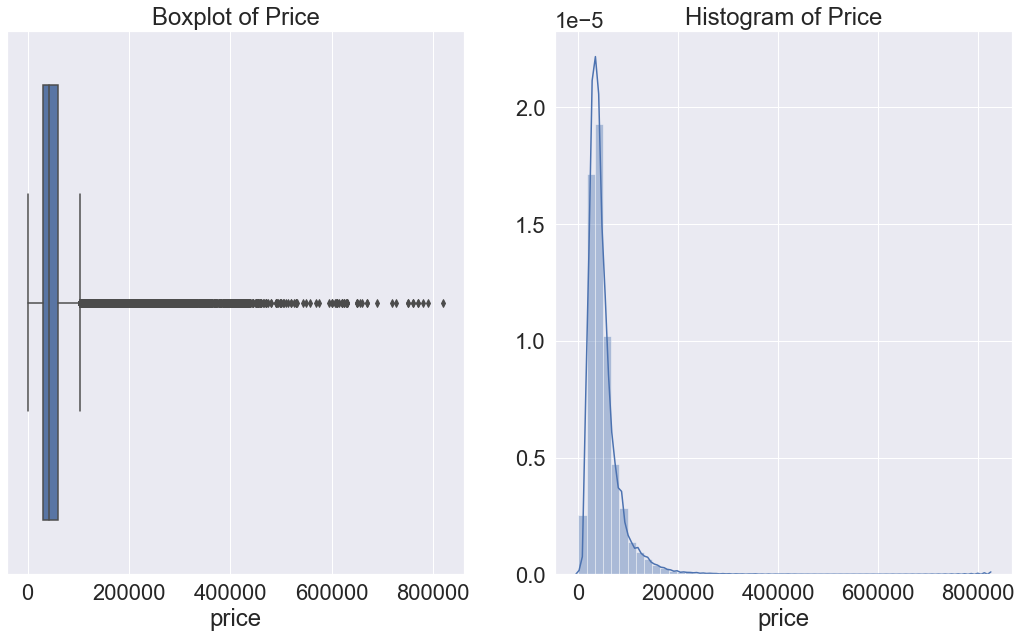

```python
sns.set(font_scale = 2)
fig, axs = plt.subplots(ncols =2, figsize=(18,10))

sns.boxplot(x='price', data=df, ax=axs[0]).set_title('Boxplot of Price')

sns.distplot(df['price'], ax=axs[1]).set_title('Histogram of Price')
```

## 2.2 거래연도 분포 확인/ 거래연도별 가격 분포 확인

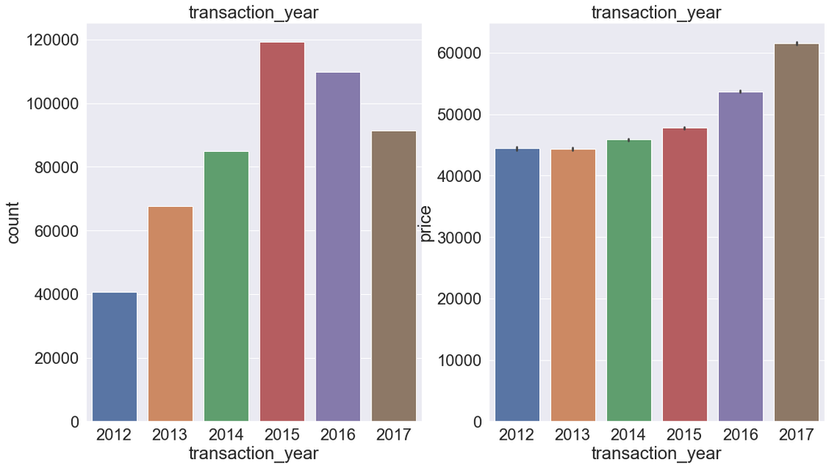

```python
sns.set(font_scale = 2)
fig, axs = plt.subplots(ncols =2, figsize=(18,10))

sns.countplot(x='transaction_year', data=df, ax=axs[0]).set_title('transaction_year')

sns.barplot(x='transaction_year', y='price', data=df, ax=axs[1]).set_title('transaction_year')
```

거래 연도별 거래 횟수와 거래 가격이 큰 연관이 없어 보인다. 거래 연도별 거래 횟수와 상관없이 거래 가격은 연도가 지남에 따라 점차 상승하는 모양새을 띄고 있음을 알수 있다.

## 2.3 층 분포 확인 / 층별 가격 분포 확인

```
'고층일수록 비싸지 않을까?'라는 가설 확인 위함
```

```
[[]]
```

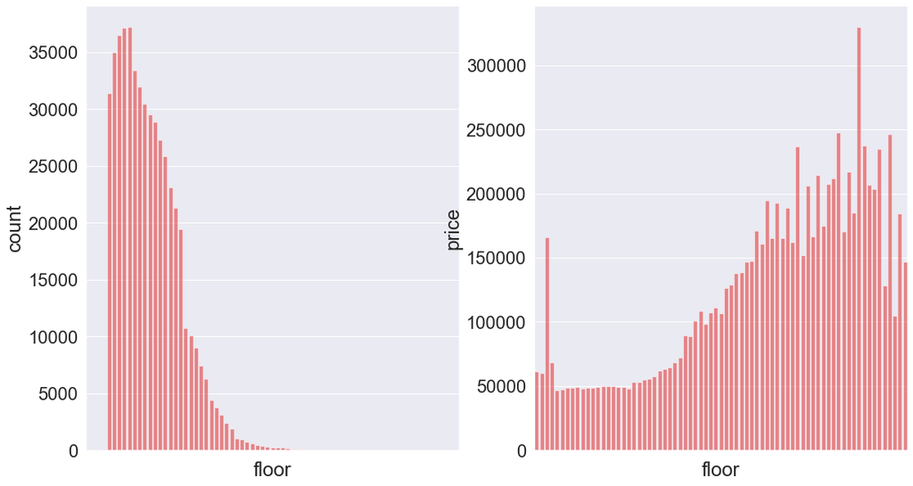

```python
sns.set(font_scale = 2)
fig, axs = plt.subplots(ncols =2, figsize=(18,10))

sns.countplot(x='floor', data=df, ax=axs[0],color='red', alpha=0.5).set(xticklabels=[])
sns.barplot(x='floor', y='price', data=df, ax=axs[1], color='red', alpha=0.5, ci=None).set(xticklabels=[])
```

대체로 층수가 높아 짐에 따라 가격이 상승하는 형상을 띄고 있으나 일정 수준 이상의 층에 도달하게 되면 가격이 더 이상 오르지 않고 오히려 하락한다는 것을 알 수 있다. 또한 거래횟수와 가격은 서로 반비례한다는 것 역시 확인할 수 있었다.

## 2.4 완공연도 분포 확인 / 완공연도별 가격 분포 확인

'최근의 아파트들이 더 비싸지 않을까?' 가설 확인 위함

```
[[]]
```

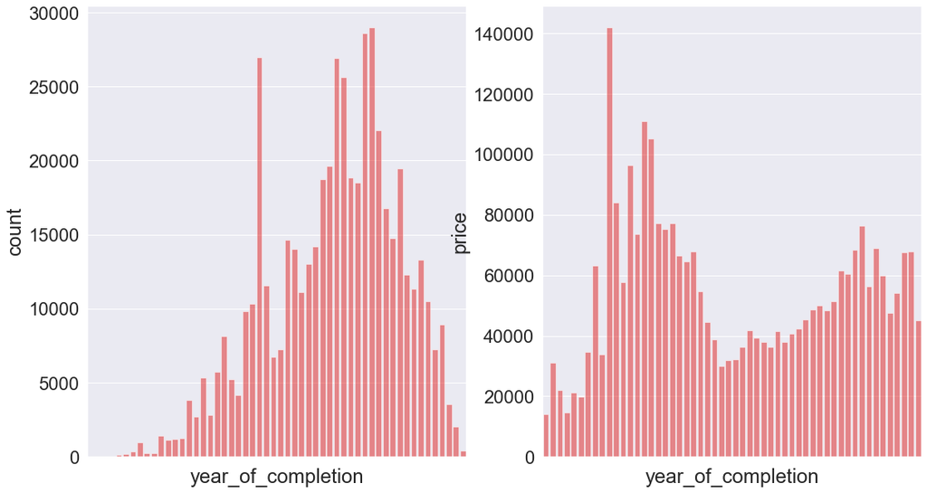

```python
sns.set(font_scale = 2)
fig, axs = plt.subplots(ncols =2, figsize=(18,10))

sns.countplot(x='year_of_completion', data=df, ax=axs[0],color='red', alpha=0.5).set(xticklabels=[])
sns.barplot(x='year_of_completion', y='price', data=df, ax=axs[1], color='red', alpha=0.5, ci=None).set(xticklabels=[])
```

최근의 아파트들이 더 비싼 양상 보다는 거래의 횟수(빈도)가 더 많은 완공연도(비교적 최근)에 해당하는 가격은 상대적으로 낮고 거래의 횟수가 적은 완공연도(대부분 오래된 아파트들)에 해당하는 가격은 상대적으로 높게 형성되어 있음을 확인 할 수 있다.

# 3. 파생변수 생성

## 3.1 아파트 연차 변수 생성

'아파트 연차가 오래될수록 거래가격이 낮지 않을까?'가설

```python
until_trans=2021-df['year_of_completion']
df['until_trans']=until_trans
df.columns
df['until_trans']
```

```
0         13
1         13
2         13
3         16
4         16
          ..
513523    10
513524    12
513525    12
513526    12
513527    10
Name: until_trans, Length: 513528, dtype: int64
```

```python
df.columns
```

```
Index(['dong', 'apt', 'addr_kr', 'exclusive_use_area', 'year_of_completion',
       'transaction_year_month', 'transaction_date', 'floor', 'price',
       'transaction_year', 'transaction_month', 'until_trans'],
      dtype='object')
```

```
[[]]
```

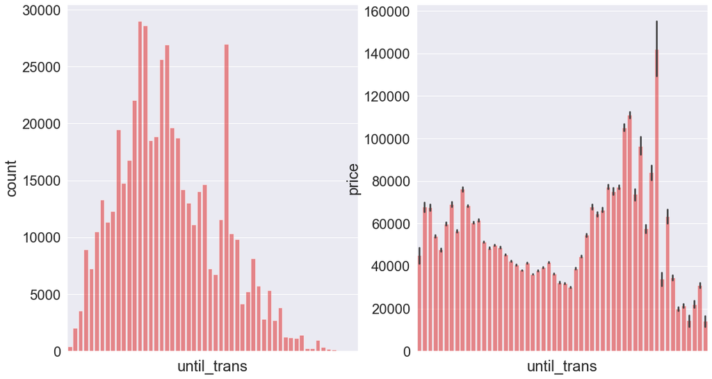

```python
sns.set(font_scale = 2)
fig, axs = plt.subplots(ncols =2, figsize=(18,10))

sns.countplot(x='until_trans', data=df, ax=axs[0],color='red', alpha=0.5).set(xticklabels=[])
sns.barplot(x='until_trans', y='price', data=df, ax=axs[1], color='red', alpha=0.5).set(xticklabels=[])
```

아파트 연차가 오래되면 오히려 거래가격이 높은 양상을 띄고 있어 '아파트 연차가 오래될수록 거래가격이 낮지 않을까?'라는 가정은 유의미하지 않다는 것을 확인할 수 있었다. 또한, 재건축&재개발 근거법령에 따르면 재개발은 준공일 기준으로 20년이상 40년이하의 건물들 중에서 선정하게 되는데 재개발의 여무?(확률?)이 아파트의 가격에 영향을 미칠 것 같아 이를 확인할 수 있도록 재건축,재개발 확률과 관련된 파생변수를 만들 수 있을 것같다

## 3.2 거래 일 변수 변환

1 ~ 10은 0으로, 11 ~ 20은 1로, 21 ~ 28 / 21 ~ 29 / 21 ~ 30 / 21 ~ 31은 2로 변환

```python
df['transaction_date']
```

```
0          1~10
1         11~20
2         11~20
3          1~10
4         21~31
          ...
513523    11~20
513524    21~30
513525    21~30
513526    21~30
513527    21~30
Name: transaction_date, Length: 513528, dtype: object
```

```python
df['transaction_date']=np.where(df['transaction_date']=='1~10','0',df['transaction_date'])
df['transaction_date']=np.where(df['transaction_date']=='11~20','1',df['transaction_date'])
df['transaction_date']=np.where(df['transaction_date']=='21~30','2',df['transaction_date'])
df['transaction_date']=np.where(df['transaction_date']=='21~28','2',df['transaction_date'])
df['transaction_date']=np.where(df['transaction_date']=='21~29','2',df['transaction_date'])
df['transaction_date']=np.where(df['transaction_date']=='21~31','2',df['transaction_date'])
```

```python
pd.unique(df['transaction_date'])
```

```
array(['0', '1', '2'], dtype=object)
```

## 3.3 월 변수와 10일 단위 변수 통합

10일 단위로 월/일 변수를 통합하는 과정

```python
df['transaction_month']=df['transaction_month'].astype(int)
df['transaction_date']=df['transaction_date'].astype(int)
```

```python
transaction_month_date=df['transaction_month']*3+df['transaction_date']
df['transaction_month_date']=transaction_month_date
```

```python
df[['transaction_month_date','transaction_month', 'transaction_date']]
```

|  | transaction_month_date | transaction_month | transaction_date |
| --- | --- | --- | --- |
| 0 | 3 | 1 | 0 |
| 1 | 4 | 1 | 1 |
| 2 | 4 | 1 | 1 |
| 3 | 3 | 1 | 0 |
| 4 | 5 | 1 | 2 |
| ... | ... | ... | ... |
| 513523 | 34 | 11 | 1 |
| 513524 | 35 | 11 | 2 |
| 513525 | 35 | 11 | 2 |
| 513526 | 35 | 11 | 2 |
| 513527 | 35 | 11 | 2 |

513528 rows × 3 columns

## 3.4 연도별 주기성을 위한 파생변수 생성 (삼각변환)

- 변수명은 sin_date, cos_date
- year_of_completion, transaction_year_month, transaction_date, transaction_month, transaction_month_date 변수 제거

```python
import math
# 삼각변환 위한 패키지
```

```python
sin_date=np.sin(2*np.pi*df.transaction_month_date/36) # 주기가 연도별&10일씩 묶었음-> (12달*3)=36
cos_date=np.cos(2*np.pi*df.transaction_month_date/36) # 2*pi*transaction_month_date는 원의 둘레!
# np.sin/cos 쓰면 오류 안나는데 math.sin/cos쓰면 오류남...why?
```

```python
new_df=df.drop(['year_of_completion','transaction_year_month','transaction_date','transaction_month','transaction_month_date'],axis=1)
new_df.columns
```

```
Index(['dong', 'apt', 'addr_kr', 'exclusive_use_area', 'floor', 'price',
       'transaction_year', 'until_trans'],
      dtype='object')
```

```python
new_df['sin_date']=sin_date
new_df['cos_date']=cos_date
new_df.columns
```

```
Index(['dong', 'apt', 'addr_kr', 'exclusive_use_area', 'floor', 'price',
       'transaction_year', 'until_trans', 'sin_date', 'cos_date'],
      dtype='object')
```

## 3.5 삼각변환을 통한 장점

삼각변환을 하지않고 시기별로 dummy(one-hot)을 잡거나 label인코딩을 하게 된다면 실제로는 간소한 차이의 시간간격임에도 불구하고 너무 큰 간격으로 인식하는 문제가 발생하게 된다. 또한 데이터 속에 숨겨진 규칙인 주기성을 발견하기가 어렵다는 단점도 존재한다.

# 4. 텍스트 데이터 다루기

## 4.1 아파트 이름 한글부분만 뽑기

- 아파트의 이름만 가져와서, 한글만 남기기 (apt)
- 특수문자/숫자 제거

```python
pd.unique(df['apt'])
```

```
array(['광화문풍림스페이스본(9-0)', '로얄팰리스스위트', '현대뜨레비앙', ..., '현대제이드', '풍천',
       '래미안강동팰리스'], dtype=object)
```

```python
type(df['apt'][0])
```

```
str
```

```python
type(df['apt'])
```

```
pandas.core.series.Series
```

```python
apt=df['apt']
apt
```

```
0         광화문풍림스페이스본(9-0)
1         광화문풍림스페이스본(9-0)
2         광화문풍림스페이스본(9-0)
3                로얄팰리스스위트
4                로얄팰리스스위트
               ...
513523          고덕리엔파크2단지
513524          강일리버파크3단지
513525          강일리버파크3단지
513526          강일리버파크1단지
513527          고덕리엔파크2단지
Name: apt, Length: 513528, dtype: object
```

```python
import re
apt2=[]
for i in apt:
    hangul=re.compile('[^ ㄱ-ㅣ가-힣]+') # 한글과 띄어쓰기를 제외한 모든 글자(정규표현식)
    repl=''
    result=re.sub(pattern=hangul, repl=repl, string=i)
    apt2.append(result)
apt2
```

```
['광화문풍림스페이스본',
 '광화문풍림스페이스본',
 '광화문풍림스페이스본',
 '로얄팰리스스위트',
 '로얄팰리스스위트',
 '로얄팰리스스위트',
 '로얄팰리스스위트',
 '현대뜨레비앙',
 '현대뜨레비앙',
 '현대뜨레비앙',
 '운현신화타워',
 '창신쌍용',
 '창신쌍용',
 '동대문',
 '두산',
 '창신쌍용',
 '종로청계힐스테이트',
 '동일상가',
 '렉스팰리스',
 '삼성',
 '프라임캐슬케이빌라트',
 '대아파크빌',
 '광화문풍림스페이스본',
 '세종로대우',
 '파크팰리스',
 '킹스매너',
 '경희궁의아침단지',
 '로얄팰리스스위트',
 '로얄팰리스스위트',
 '현대뜨레비앙',
 '현대뜨레비앙',
 '운현신화타워',
 '현대뜨레비앙',
 '동성아파트동',
 '아남',
 '아남',
 '아남',
 '아남',
 '아남',
 '창신쌍용',
```

[output cut: 946 more lines]

```
 '광화문풍림스페이스본',
 '광화문풍림스페이스본',
 '경희궁의아침단지',
 '신문로맨션',
 '로얄팰리스스위트',
 '현대뜨레비앙',
 '현대뜨레비앙',
 '효성쥬얼리시티',
 '효성쥬얼리시티',
 '이화에수풀',
 '건양하늘터',
 '아남',
 '두산',
 '창신쌍용',
 ...]
```

## 4.2 아파트 이름 DTM

- 아파트 이름에 대한 문서단어행렬 만들기

```python
from sklearn.feature_extraction.text import CountVectorizer
```

```python
#apt=[apt]
vect=CountVectorizer(min_df=5)
vect.fit(apt2)
vect.vocabulary_
```

```
{'광화문풍림스페이스본': 271,
 '로얄팰리스스위트': 1042,
 '현대뜨레비앙': 3814,
 '운현신화타워': 2739,
 '창신쌍용': 3197,
 '동대문': 771,
 '두산': 892,
 '종로청계힐스테이트': 3077,
 '동일상가': 862,
 '렉스팰리스': 1028,
 '삼성': 1630,
 '대아파크빌': 627,
 '세종로대우': 2038,
 '파크팰리스': 3480,
 '킹스매너': 3377,
 '경희궁의아침단지': 186,
 '동성아파트동': 809,
 '아남': 2371,
 '동아': 820,
 '롯데캐슬': 1059,
 '로잔': 1045,
 '크래스빌': 3368,
 '롯데낙천대': 1055,
 '인왕산아이파크': 2923,
 '현대': 3800,
 '미도파': 1293,
 '효성쥬얼리시티': 3967,
 '종로센트레빌': 3073,
 '대성맨션': 614,
 '청운현대': 3301,
 '타워': 3380,
 '렉스빌': 1027,
 '창신이수': 3198,
 '브라운스톤창신': 1555,
 '벽산블루밍평창힐스': 1463,
 '갑을': 30,
 '그린동': 317,
 '르트랑시망': 1092,
 '무악다온채': 1258,
 '세종': 2035,
```

[output cut: 946 more lines]

```
 '젬스톤타운': 3066,
 '수유역두산위브': 2104,
 '수유삼호': 2103,
 '수유현대': 2107,
 '삼성빌리지': 1658,
 '영남': 2555,
 '삼성래미안트리베라단지': 1651,
 '현대꿈에그린': 3808,
 '정원': 3033,
 '신일해피트리': 2300,
 '꿈의숲수림채': 401,
 '미아신구': 1317,
 '훼밀리': 3984,
 '청솔': 3275,
 ...}
```

## 4.3 아파트 이름 tf-idf

```python
from sklearn.feature_extraction.text import TfidfVectorizer
```

```python
tfidv = TfidfVectorizer(min_df=5).fit(apt2)
tfidv.transform(apt2).toarray()
```

```
array([[0., 0., 0., ..., 0., 0., 0.],
       [0., 0., 0., ..., 0., 0., 0.],
       [0., 0., 0., ..., 0., 0., 0.],
       ...,
       [0., 0., 0., ..., 0., 0., 0.],
       [0., 0., 0., ..., 0., 0., 0.],
       [0., 0., 0., ..., 0., 0., 0.]])
```

## 4.4 질문

다중공산성 문제가 발생할 수도 있으며,,,, 임베딩의 의미와 다르게 해석될..? 상관없는영향을 미칠 수도 있다..?

## 4.5 질문

잘모르겟...

# 5. 인코딩

```python
df3=new_df.drop(columns=['addr_kr'])
```

```python
df3.columns
```

```
Index(['dong', 'apt', 'exclusive_use_area', 'floor', 'price',
       'transaction_year', 'until_trans', 'sin_date', 'cos_date'],
      dtype='object')
```

## 5.1 원핫 인코딩

```python
dong_onehot=pd.get_dummies(df3['dong'])
apt_onehot=pd.get_dummies(df3['apt'])
print(dong_onehot.shape, apt_onehot.shape)
```

```
(513528, 329) (513528, 6765)
```

차원이 너무 크고 dong과 apt의 원핫 인코딩의 col값이 서로 다르다 너무 많은 feature들이 생성되어 차원의 저주 발생

## 5.2 레이블(label) 인코딩- Transaction_year

transaction_year에 대해 label 인코딩 시행

```python
from sklearn.preprocessing import LabelEncoder

encoder=LabelEncoder()
encoder.fit(df3['transaction_year'])

labels=encoder.transform(df3['transaction_year'])
df3['transaction_year']=labels
```

```python
df3.head()
```

|  | dong | apt | exclusive_use_area | floor | price | transaction_year | until_trans | sin_date | cos_date |
| --- | --- | --- | --- | --- | --- | --- | --- | --- | --- |
| 0 | 사직동 | 광화문풍림스페이스본(9-0) | 95.88 | 6 | 70000 | 0 | 13 | 0.500000 | 0.866025 |
| 1 | 사직동 | 광화문풍림스페이스본(9-0) | 108.55 | 11 | 100500 | 0 | 13 | 0.642788 | 0.766044 |
| 2 | 사직동 | 광화문풍림스페이스본(9-0) | 94.51 | 1 | 65800 | 0 | 13 | 0.642788 | 0.766044 |
| 3 | 수송동 | 로얄팰리스스위트 | 42.87 | 8 | 30500 | 0 | 16 | 0.500000 | 0.866025 |
| 4 | 수송동 | 로얄팰리스스위트 | 39.67 | 15 | 30500 | 0 | 16 | 0.766044 | 0.642788 |

2.2 시각화에 따르면 거래 연도별 거래 횟수와 상관없이 거래 가격은 연도가 지남에 따라 점차 상승하는 모양새을 띄어 서로 관련이 없기에 이러한 인코딩을 별로 유의미하다고 볼 수 없다.

## 5.3 레이블(label) 인코딩

dong과 apt에 대해 레이블 인코딩 시행

```python
encoder=LabelEncoder()

dong_encoder=encoder.fit(df3['dong'])
dong_labels=dong_encoder.transform(df3['dong'])

apt_encoder=encoder.fit(df3['apt'])
apt_labels=apt_encoder.transform(df3['apt'])

df3['dong']=dong_labels
df3['apt']=apt_labels
```

```python
df3.head()
```

|  | dong | apt | exclusive_use_area | floor | price | transaction_year | until_trans | sin_date | cos_date |
| --- | --- | --- | --- | --- | --- | --- | --- | --- | --- |
| 0 | 130 | 805 | 95.88 | 6 | 70000 | 0 | 13 | 0.500000 | 0.866025 |
| 1 | 130 | 805 | 108.55 | 11 | 100500 | 0 | 13 | 0.642788 | 0.766044 |
| 2 | 130 | 805 | 94.51 | 1 | 65800 | 0 | 13 | 0.642788 | 0.766044 |
| 3 | 164 | 2042 | 42.87 | 8 | 30500 | 0 | 16 | 0.500000 | 0.866025 |
| 4 | 164 | 2042 | 39.67 | 15 | 30500 | 0 | 16 | 0.766044 | 0.642788 |

one-hot encoding처럼 많은 feature를 생성하지 않고 하나의 labeled feature만 만들기에 원핫보다 학습속도가 빠르다는 장점이 있으나 피처 값들을 numeric한 형태로 인코딩하기 때문에 순서개념이 없는 categorical한 값들까지도 순서개념을 전제하여 학습하게 된다.

## 5.4 mean encoding

apt에 대해 mean encoding을 시행

```python
apt_mean=df3.groupby('apt')['price'].mean()
apt_mean
```

```
apt
0        15000.000000
1        18000.000000
2        84250.000000
3        11599.107143
4        27585.714286
            ...
6760     20480.000000
6761     53416.666667
6762     72900.000000
6763    124666.666667
6764     80000.000000
Name: price, Length: 6765, dtype: float64
```

```python
df3['apt']=df3['apt'].map(apt_mean)
```

```python
df3.head()
```

|  | dong | apt | exclusive_use_area | floor | price | transaction_year | until_trans | sin_date | cos_date |
| --- | --- | --- | --- | --- | --- | --- | --- | --- | --- |
| 0 | 130 | 91174.766355 | 95.88 | 6 | 70000 | 0 | 13 | 0.500000 | 0.866025 |
| 1 | 130 | 91174.766355 | 108.55 | 11 | 100500 | 0 | 13 | 0.642788 | 0.766044 |
| 2 | 130 | 91174.766355 | 94.51 | 1 | 65800 | 0 | 13 | 0.642788 | 0.766044 |
| 3 | 164 | 36609.649123 | 42.87 | 8 | 30500 | 0 | 16 | 0.500000 | 0.866025 |
| 4 | 164 | 36609.649123 | 39.67 | 15 | 30500 | 0 | 16 | 0.766044 | 0.642788 |

mean encoding은 내가 encoding 하는 feature와 예측하려는 target간의 수치적인 관계를 categorical 변수에서도 찾자는 것으로 label값을 수치적으로 표현하면서도, 서로 구분할 수 있다는 특징을 갖고 있다. 차원의 저주가 없고 학습이 빠르며 편차가 작다는 장점이 있으나 오버피팅의 위험도가 존재한다.